# Part II - The influence of trip data characteristics on their duration

## by Nguyen Huu Tuan

## Investigation Overview

The purpose of this study was to analyze the trip data characteristics that have predictive value for trip duration. The primary emphasis was placed on investigating five key variables: age, start station, end station, user type, and gender. The objective was to examine how these factors contribute to predicting the duration of trips.

## Dataset Overview

The dataset for fordgobike contains a total of 183,411 rowa and 16 columns ('duration_sec', 'start_time', 'end_time', 'start_station_id', 'start_station_name', 'start_station_latitude', 'start_station_longitude', 'end_station_id', 'end_station_name', 'end_station_latitude', 'end_station_longitude', 'bike_id', 'user_type', 'member_birth_year', 'member_gender', 'bike_share_for_all_trip'). In the dataset, have 7 columns float, 2 columms int and 7 columns object. Column 'start_time' and 'and_time' are time, convert from object to datetime.

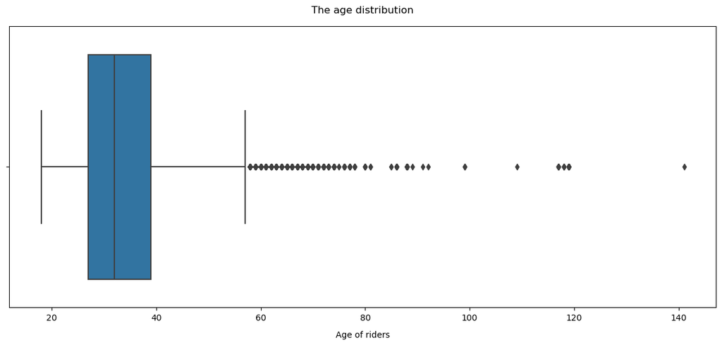

## Count of daily bike rides

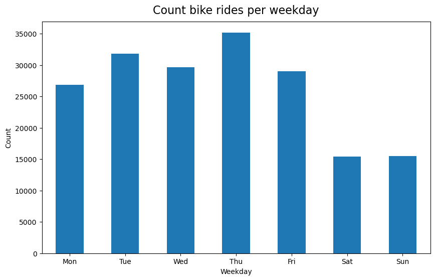

## Using Times of Biker

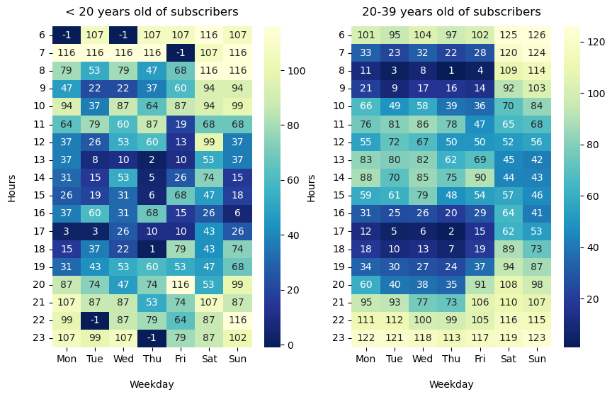

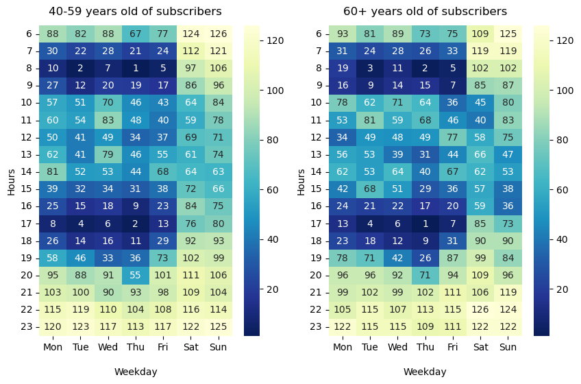